# Celebrity COVID Cases

March 26, 2020

# Summary of data

|  | F (N=17) | M (N=53) | Overall (N=71) |
| --- | --- | --- | --- |
| Career |  |  |  |
| Entertainment | 10 (58.8%) | 16 (30.2%) | 26 (36.6%) |
| Other | 3 (17.6%) | 3 (5.7%) | 6 (8.5%) |
| Politician | 4 (23.5%) | 16 (30.2%) | 21 (29.6%) |
| Athlete | 0 (0%) | 18 (34.0%) | 18 (25.4%) |
| Age |  |  |  |
| (15,25] | 1 (5.9%) | 6 (11.3%) | 7 (9.9%) |
| (25,35] | 4 (23.5%) | 7 (13.2%) | 11 (15.5%) |
| (35,55] | 6 (35.3%) | 15 (28.3%) | 21 (29.6%) |
| (55,85] | 6 (35.3%) | 20 (37.7%) | 26 (36.6%) |
| Missing | 0 (0%) | 5 (9.4%) | 6 (8.5%) |

Our current data contain more than three times as many male celebrities as female celebrities. Part of the difference is due to a large number of male athletes being tested and a large difference in the number of male politicians tested.

Net worth of celebrites tested for COVID (in millions).

| Category_career | Mean | SD | n |
| --- | --- | --- | --- |
| Athlete | 39.9 | 53.7 | 12 |
| Entertainment | 1592.9 | 7414.6 | 24 |
| Other | 50.8 | 52.4 | 4 |
| Politician | 313.3 | 844.7 | 14 |

Instagram followers of celebrites tested for COVID (in thousands).

| Category_career | Mean | SD | n |
| --- | --- | --- | --- |
| Athlete | 2652.9 | 3826.7 | 9 |
| Entertainment | 8545.9 | 19645.3 | 19 |
| Other | 670.6 | 600.6 | 5 |
| Politician | 1809.6 | 5069.1 | 13 |

Celebrities in the entertainment industry had the highest net worth on average, followed by politicians. Entertainment celebrities also had the most instagram followers followed by celebrities, on average.

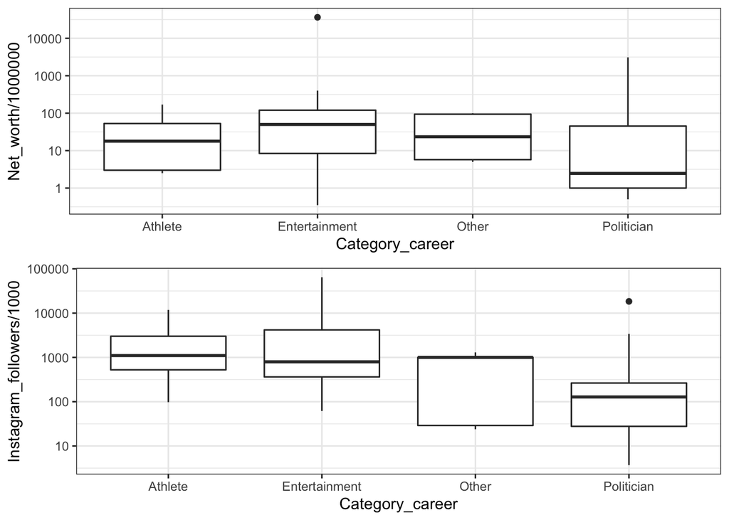

Celebrity net worth and followers by career type.

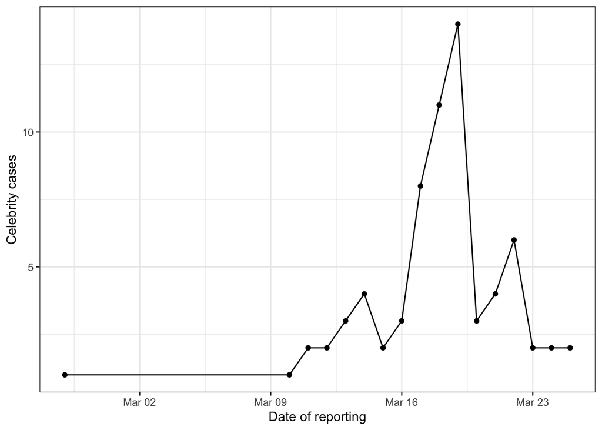

Celebrity coronavirus cases by reporting date in our dataset.

Reports of celebrity coronavirus cases peaked on March 19th and has trailed off.

# Univariate analyses of delay distributions

Here, we want to see the overall delay distributions of all celebrities.

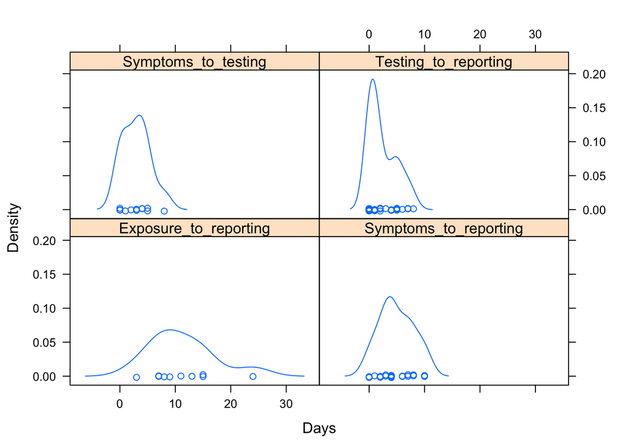

Delay distributions of celebrity cases.

```
##  Exposure_to_reporting Symptoms_to_testing Testing_to_reporting
##  Min.   : 3.00         Min.   :0.000       Min.   :0.000
##  1st Qu.: 7.25         1st Qu.:0.750       1st Qu.:0.000
##  Median :10.00         Median :3.000       Median :1.000
##  Mean   :11.20         Mean   :2.917       Mean   :2.355
##  3rd Qu.:14.50         3rd Qu.:4.250       3rd Qu.:4.500
##  Max.   :24.00         Max.   :8.000       Max.   :8.000
##  NA's   :61            NA's   :59          NA's   :40
##  Symptoms_to_reporting
##  Min.   : 0.000
##  1st Qu.: 3.000
##  Median : 4.000
##  Mean   : 4.957
##  3rd Qu.: 7.000
##  Max.   :10.000
##  NA's   :48
```

Celebrities are being tested 2.9 days after symptom onset, on average with a median of 3 days. They are getting their results back 2.4 days after testing, with a median of 1 day.

# Multivariate analyses

Response variables:

- exposure to symptoms
- exposure to testing
- exposure to reporting
- symptoms to testing
- symptoms to reporting
- testing to reporting

Predictor variables:

- age
- sex
- symptoms binary
- career category
- net worth
- insta followers
- country

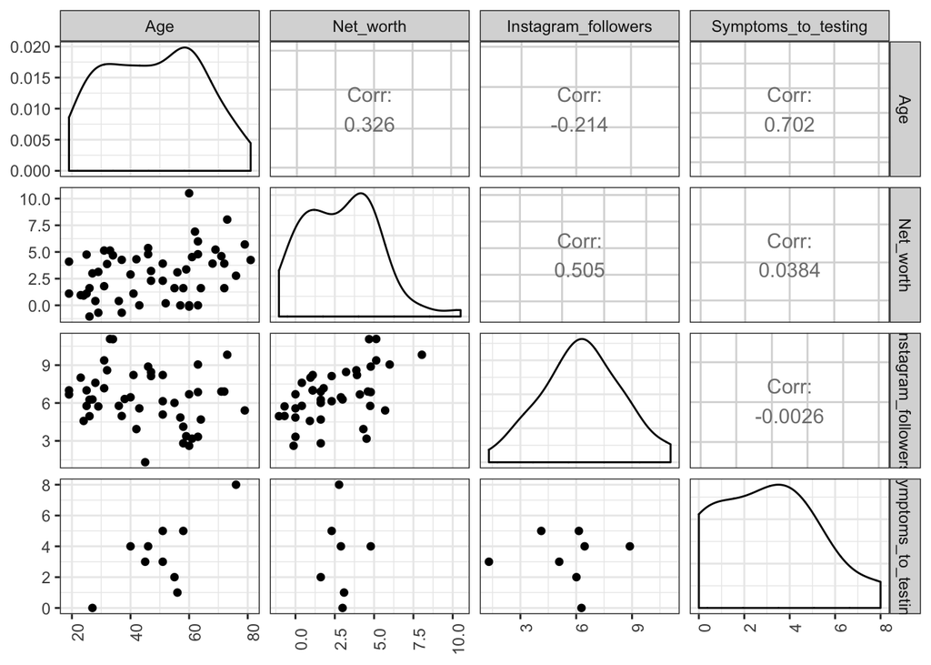

Symptom to testing delay by age, net worth, and instagram followers.

Older age is POSITIVELY correlated with symptom to testing delay. Not what we expected. Net worth and instagram followership is not associated with symptom to testing delay.

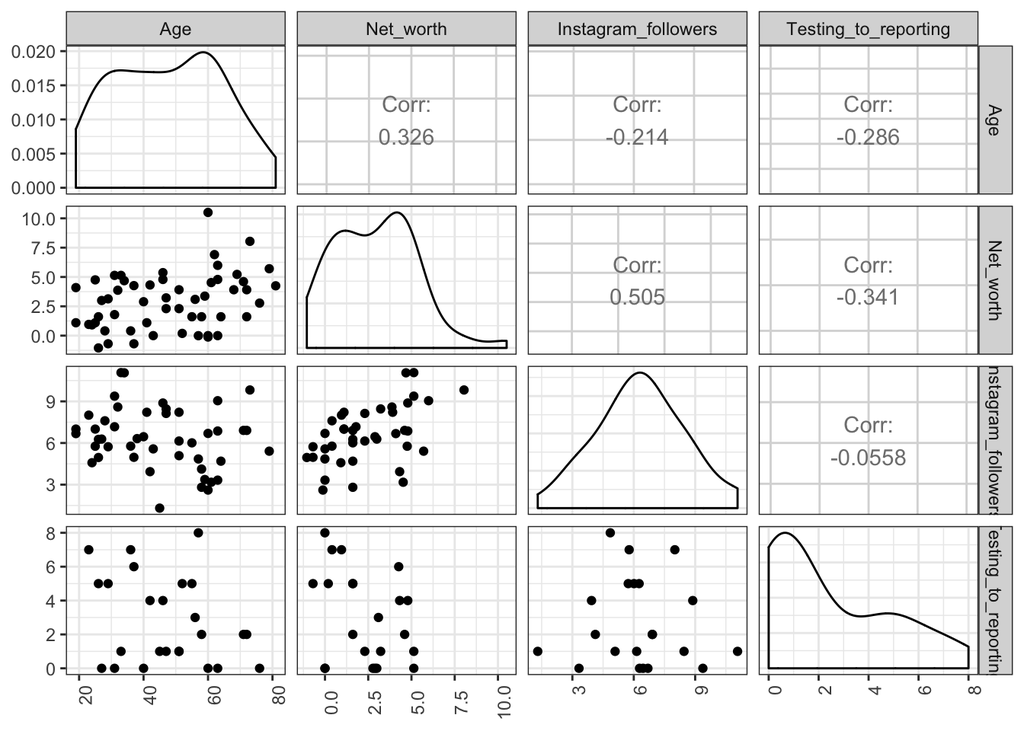

Testing to reporting delay by age, net worth, and instagram followers.

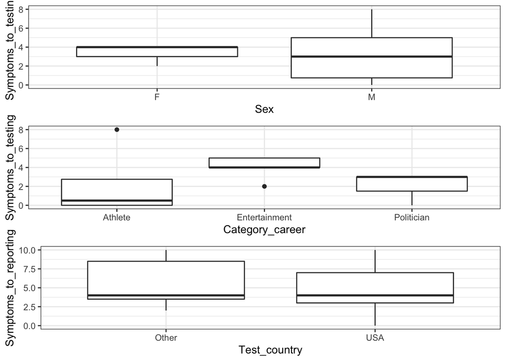

The most apparent difference in symptom to testing delay is by celebrity career type. Athletes were tested very quickly following a scare with a few infected players lowering their average.

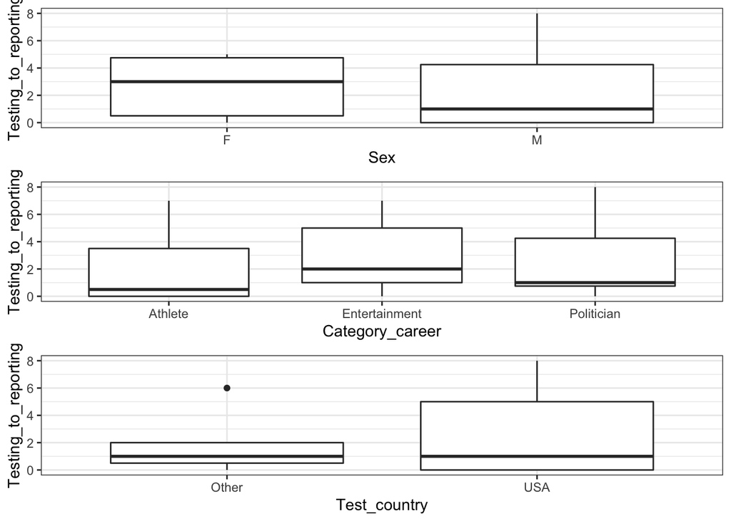

Testing to reporting delay by sex, career category, and test country.